# Engenharia de Atributos

Wesley Galvão

## Apresentação

- Cientista de dados sênior, com passagem pelas indústrias de e-commerce e de RH Tech.
- Engenheiro de computação.
- Mestre em ciência da computação, na linha de visão computacional.
- Doutorando em visão computacional.

# Por que engenharia de atributos

## O que é engenharia de atributos

- Um modelo recebe uma tabela: uma linha por unidade de análise, uma coluna por atributo.
- A pergunta de negócio raramente corresponde às colunas que existem na fonte.
- Engenharia de atributos é construir as colunas que faltam, a partir do domínio e da estrutura dos dados.
- As aulas de checagens de integridade, de imputação de valores ausentes, de transformação, de discretização e codificação e de detecção de outliers trabalharam sobre colunas **que já existem**. Hoje criamos colunas novas.
- Na aula de introdução vimos que cerca de 80% do tempo de um projeto vai para preparação. Mudar as colunas de entrada costuma alterar o desempenho mais do que trocar o algoritmo.

# Como os dados existem numa empresa

## Data lake e data warehouse

[figure not shown]

O banco que registra a venda é transacional: escreve rápido, e consulta analítica nele concorre com a operação. Por isso o dado é copiado para um destes ambientes antes de ser analisado.

## Camadas de dados

[figure not shown]

A engenharia de atributos acontece na passagem de silver para gold: as colunas novas são construídas a partir da silver e gravadas na gold.

## Técnicas de criação de atributos

[figure not shown]

# O caso de uso

## O conjunto de dados Olist

- A Olist é um marketplace brasileiro: o lojista se cadastra uma vez e passa a vender nos grandes portais, enquanto a Olist intermedeia pagamento e logística.
- Um pedido pode reunir itens de **vendedores diferentes**, e cada vendedor despacha a sua parte separadamente.
- Depois da entrega, o cliente recebe um questionário e dá uma **nota de 1 a 5**, com comentário livre.
- Publicado no Kaggle em 2018: cerca de 100 mil pedidos reais, entre setembro de 2016 e outubro de 2018, anonimizados.

## As nove tabelas

```
tabela            linhas  o que registra
pedidos           99.441  # um pedido por linha e as datas do ciclo
itens            112.650  # um item por linha: produto e vendedor
pagamentos       103.886  # forma de pagamento, parcelas e valor
avaliações        99.224  # a nota de 1 a 5 dada pelo cliente
clientes          99.441  # um registro por pedido, cidade e CEP
vendedores         3.095  # o lojista, com cidade, estado e CEP
produtos          32.951  # categoria, dimensões e peso do produto
geolocalização 1.000.163  # latitude e longitude por prefixo de CEP
tradução              71  # nome da categoria em inglês
```

- Cada tabela tem uma granularidade diferente, e a chave primária de cada uma é diferente.
- O aspecto relacional permite juntar tabelas, mas a junção precisa preservar a unidade de análise.

## O diagrama de relacionamento

[figure not shown]

## As três camadas, no mesmo pedido

[figure not shown]

## Tipos de pergunta de negócio

| tipo | pergunta | quando a resposta é usada |
| --- | --- | --- |
| descritiva | quantos pedidos foram mal avaliados no mês? | depois, para acompanhar |
| diagnóstica | por que esses clientes reclamaram? | depois, para corrigir a causa |
| **preditiva** | **este pedido vai ser mal avaliado?** | **antes do desfecho** |
| prescritiva | o que fazer com este pedido agora? | junto com a ação |

A nossa é **preditiva**: a unidade de análise é o pedido e a previsão precisa existir no instante da compra. **A pergunta:** qual a chance de o cliente avaliar com nota 1 ou 2? O alvo é $y = 1$ para nota 1 ou 2, $y = 0$ para nota 4 ou 5.

## A restrição que a pergunta impõe

[figure not shown]

## De que depende a insatisfação

Quatro hipóteses, escritas antes de qualquer código.

| hipótese | colunas que ela gera | técnica |
| --- | --- | --- |
| H1. complexidade | `n_itens`, `n_vendedores`, `valor_total`, `frete_total` | agregação |
| H2. custo do frete | `frete_relativo` | combinação entre colunas |
| H3. distância | `distancia_km`, `mesmo_estado` | junção e binarização |
| H4. prazo e calendário | `prazo_prometido_dias`, `dia_da_semana` | data e hora |

Nenhuma das quatro existe nas 9 tabelas. A terceira coluna nomeia a técnica.

## O trabalho que vem a seguir

[figure not shown]

O laço do meio dá quatro voltas, uma por hipótese. As duas checagens de baixo valem para qualquer projeto, e não apenas para este.

## `merge`: os tipos de junção

[figure not shown]

## `merge`: juntar tabelas sem multiplicar linhas

O `merge` casa duas tabelas por uma chave, e o resultado depende da cardinalidade dela.

```python
pedidos = bronze["pedidos"][["order_id", "customer_id"]]
clientes = bronze["clientes"][["customer_id", "customer_state"]]
itens = bronze["itens"][["order_id", "price"]]

com_cliente = pedidos.merge(clientes, on="customer_id", how="left")
com_itens = pedidos.merge(itens, on="order_id", how="left")

print("pedidos                     ", pedidos.shape)
print("+ clientes   (1 para 1)     ", com_cliente.shape)
print("+ itens      (1 para N)     ", com_itens.shape)
```

```
pedidos                      (99441, 2)
+ clientes   (1 para 1)      (99441, 3)
+ itens      (1 para N)      (113425, 3)
```

- `on` é a chave, `how="left"` preserva todas as linhas da esquerda.
- O segundo `merge` criou quase 14 mil linhas, e o pedido deixou de ser a unidade.

## Granularidade: agregue antes de juntar

[figure not shown]

# Construindo a tabela gold

## A linha de base

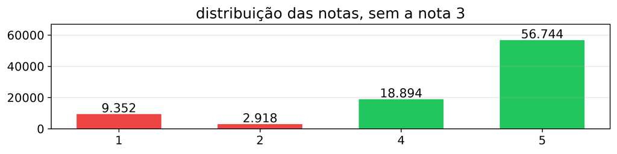

- A nota 3 sai da base. Ela não separa cliente satisfeito de insatisfeito, e mantê-la de um lado ou de outro embaralharia a fronteira que queremos aprender.
- Sobram 87.908 pedidos entregues e avaliados. Linha de base: **14,0%** de avaliação ruim. Toda coluna nova será medida contra esse número.

## H1: complexidade do pedido

**Hipótese.** Cada vendedor despacha a sua parte separadamente, então mais itens e mais vendedores significam mais entregas independentes, e basta uma falhar.

**Definição (agregação).** Somando sobre os itens $i$ de um mesmo pedido: $n$ é quantos itens ele tem, $m$ quantos vendedores distintos aparecem, $v = \sum_i v_i$ é o valor e $f = \sum_i f_i$ é o frete. `groupby` diz por qual chave agrupar e `agg` diz o que fazer com cada grupo.

```python
itens = bronze["itens"]

por_pedido = itens.groupby("order_id").agg(
    n_itens=("order_item_id", "size"),
    n_vendedores=("seller_id", "nunique"),
    valor_total=("price", "sum"),
    frete_total=("freight_value", "sum"),
)

print("antes:", itens.shape, "   depois:", por_pedido.shape)
```

```
antes: (112650, 7)    depois: (98666, 4)
```

## H1: a tabela até aqui

| order_id | pedido 30408639 | pedido 561a3b9c | pedido 6386b8aa |
| --- | --- | --- | --- |
| n_itens | 3 | 2 | 2 |
| n_vendedores | 3 | 2 | 2 |
| valor_total | 197.89 | 67.15 | 85.80 |
| frete_total | 60.96 | 31.76 | 16.12 |

**4 colunas.**

## H1: itens e vendedores por pedido

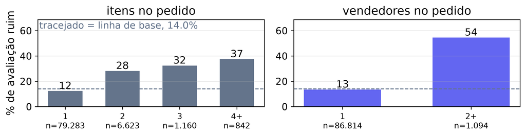

- Pedido de 4 itens ou mais: **37,4%** contra 12,3% do pedido de item único.
- Mais de um vendedor: **54,5%**, quase quatro vezes a linha de base.
- A leitura de negócio é a mesma nos dois casos: mais partes independentes, mais chances de uma delas falhar, e o cliente avalia o conjunto.

## H2: custo relativo do frete

**Hipótese.** O que incomoda não é o frete alto em reais, e sim o frete alto em relação ao que se está comprando.

**Definição (combinação entre colunas).** $r = f / v$, o frete dividido pelo valor do mesmo pedido: as duas colunas que o `agg` de H1 já produziu.

```python
gold["frete_relativo"] = gold["frete_total"] / gold["valor_total"]
```

- Nenhum `groupby` e nenhum `merge`: a coluna nova sai de uma operação entre duas colunas da mesma linha.
- A razão é a forma mais comum de combinação, mas não a única: diferença, produto e comparação com o típico do grupo estão no catálogo.

## H2: a tabela até aqui

| order_id | pedido 30408639 | pedido 561a3b9c | pedido 6386b8aa |
| --- | --- | --- | --- |
| n_itens | 3 | 2 | 2 |
| n_vendedores | 3 | 2 | 2 |
| valor_total | 197.89 | 67.15 | 85.80 |
| frete_total | 60.96 | 31.76 | 16.12 |
| frete_relativo | 0.31 | 0.47 | 0.19 |

**5 colunas.** `frete_relativo` é a primeira que não vem de agregação, e sim de uma razão.

## H2: frete em reais contra frete relativo

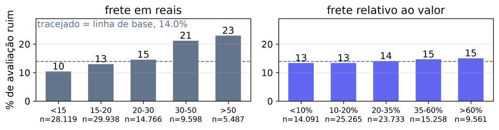

- O frete em reais vai de **10,4%** (até R$ 15) a **23,0%** (acima de R$ 50). A razão vai de 13,3% a 15,0%.
- Dividir uma coluna pela outra apagou a separação que a coluna original tinha. Nem toda combinação carrega mais informação do que as suas partes.
- A coluna fica na tabela. Decidir se ela sai é trabalho da próxima aula, com método.

## H3 e H4: distância, prazo e calendário

Duas hipóteses, três técnicas do catálogo, e a mesma evidência: a taxa de avaliação ruim por faixa da coluna.

| hipótese | coluna | técnica | menor taxa | maior taxa |
| --- | --- | --- | --- | --- |
| H3. distância | `distancia_km` | junção | 11,0%, até 200 km | 18,4%, acima de 2.000 km |
| H3. distância | `mesmo_estado` | binarização | 11,3%, mesmo estado | 15,4%, outro estado |
| H4. expectativa | `prazo_prometido_dias` | data e hora | 9,9%, até 10 dias | 17,0%, acima de 45 dias |
| H4. calendário | `dia_da_semana` | data e hora | 13,3%, quarta | 15,1%, sexta |

- `distancia_km` exigiu agregar um milhão de linhas de geolocalização, uma coordenada por CEP, antes do `merge`. `mesmo_estado` compara o estado do cliente com o do vendedor do item mais caro.
- `dia_da_semana` quase não separa. Ela volta na próxima aula, e sai lá.

## H3 e H4: a tabela até aqui

| order_id | pedido 30408639 | pedido 561a3b9c | pedido 6386b8aa |
| --- | --- | --- | --- |
| n_itens | 3 | 2 | 2 |
| n_vendedores | 3 | 2 | 2 |
| valor_total | 197.89 | 67.15 | 85.80 |
| frete_total | 60.96 | 31.76 | 16.12 |
| frete_relativo | 0.31 | 0.47 | 0.19 |
| distancia_km | 943.54 | 338.90 | 288.41 |
| mesmo_estado | False | False | True |
| prazo_prometido_dias | 39 | 16 | 22 |
| dia_da_semana | 4 | 0 | 5 |

**9 colunas.** Quatro colunas novas, três técnicas, nenhuma linha a mais na tabela. É a tabela que a próxima aula recebe.

## Tratamentos que vazam o futuro

As colunas pós-entrega são o caso óbvio de vazamento. Estes são os menos óbvios: a coluna parece conhecida na compra, mas o número que a preenche não era.

| tratamento | por onde o futuro entra |
| --- | --- |
| codificar a categoria pela taxa do alvo (*target encoding*) | a média inclui o próprio pedido, e avaliações escritas depois da compra |
| histórico do vendedor: média do alvo nos pedidos anteriores | a avaliação do pedido anterior só existe dias depois; ordenar pela compra não basta |
| contagem ou média por vendedor, por categoria, por rota, na base inteira | a estatística usa pedidos que ainda não tinham acontecido |
| imputar, escalar ou discretizar antes do split | a mediana e os cortes do teste entram no treino |

A pergunta certa não é quando o evento **aconteceu**, e sim quando o número passou a ser **conhecido**. O teste é sempre o mesmo: esse valor existia no instante da compra?

## Onde isso continua

- De 9 tabelas cruas a uma linha por pedido, com 20 colunas conhecidas no instante da compra, 9 delas construídas hoje.
- Medimos a taxa por faixa de cada uma, e nada além disso. Algumas separam muito, outras quase nada, e várias contam a mesma história: distância, estado e prazo prometido andam juntos.
- Decidir quais entram no modelo é outro problema, com método próprio, e é a próxima aula. Ela parte do arquivo abaixo e usa um modelo pronto para medir cada corte.

```
gold: 87908 linhas x 29 colunas, 20 conhecidas no instante da compra
gravada em ../dados/olist_gold_pedidos.parquet
```

## Referências

- Dataset: [Brazilian E-Commerce Public Dataset by Olist](https://www.kaggle.com/datasets/olistbr/brazilian-ecommerce), Kaggle.
- García, Luengo e Herrera. *Data Preprocessing in Data Mining*, capítulo 7.
- [Feature Engineering](https://www.datacamp.com/tutorial/feature-engineering), DataCamp.
- Prashant Banerjee, [A Reference Guide to Feature Engineering Methods](https://www.kaggle.com/code/prashant111/a-reference-guide-to-feature-engineering-methods), Kaggle.
- Ashish Patel, [A Short Guide for Feature Engineering and Feature Selection](https://github.com/ashishpatel26/Amazing-Feature-Engineering).
- Documentação pública da Databricks sobre a arquitetura em camadas (medallion).